# Project_Machine Learning

Miguel Gutierrez

27 de noviembre de 2020

## Summary

In this report we evaluate the precision of the decision tree and random forest models for predicting the type of activity performed, the database is personal activities recorded by accelerometers in 4 different parts of the body on 6 participants. A data cleaning was performed by eliminating non-relevant variables, voids (NA), zeros. The decision tree and random forest models were implemented to make the predictions. The cross-validation was applied to the "classe" variable in the training data.

## Loading data

[output not shown]

The training data for this project is available here:  
https://d396qusza40orc.cloudfront.net/predmachlearn/pml-training.csv  
The test data is available here:  
https://d396qusza40orc.cloudfront.net/predmachlearn/pml-testing.csv  
The data for this project comes from this original source: http://groupware.les.inf.puc-rio.br/har.

```r
rawTrain <- read.csv(file = "pml-training.csv")
dim(rawTrain)
```

```
## [1] 19622   160
```

```r
rawValid <- read.csv(file = "pml-testing.csv")
dim(rawValid)
```

```
## [1]  20 160
```

```r
#
str(rawTrain)
```

[output not shown]

[output cut: 86 more lines]

## Cleaning data

```r
# Selecting and removing columns with zeros
dataTrain<- rawTrain[, colSums(is.na(rawTrain)) == 0]
dim(dataTrain)
```

```
## [1] 19622    93
```

```r
dataValid <- rawValid[, colSums(is.na(rawValid)) == 0]
dim(dataValid)
```

```
## [1] 20 60
```

```r
# Selecting and removing empty columns
noemptyCols <- colSums(dataTrain == "")
dataTrain <- dataTrain[, -noemptyCols]
dataValid <- dataValid[, -noemptyCols]
# Removing columns not relevant [View str(rawTrain)]
dataTrain <- dataTrain[, -c(1:7)]
dim(dataTrain)
```

```
## [1] 19622    86
```

```r
dataValid <- dataValid[, -c(1:7)]
dim(dataValid)
```

```
## [1] 20 53
```

```r
# Selecting and removing the columns of near-zero variance
NZV <- nearZeroVar(dataTrain, saveMetrics=TRUE)
dataTrain <- dataTrain[, !NZV$nzv]
dim(dataTrain)
```

```
## [1] 19622    53
```

## Splitting the training data

the training data is splitted into 75% as train data (Training) and 25% as test data (Testing).

```r
set.seed(2020)
inTrain <- createDataPartition(y=dataTrain$classe, p=0.75, list=FALSE)
Training <- dataTrain[inTrain, ]
Testing <- dataTrain[-inTrain, ]
dim(Training)
```

```
## [1] 14718    53
```

```r
dim(Testing)
```

```
## [1] 4904   53
```

## Results: Predicts with Machine Learning algorithms

### Decision Tree

[figure not shown]

```r
modelTree <- rpart(classe ~ ., data = Training, method = "class")
fancyRpartPlot(modelTree)
```

```r
predictionsTree <- predict(modelTree, Testing, type = "class")
# The cross-validation
confusionMatrix(table(predictionsTree, Testing$classe))
```

```
## Confusion Matrix and Statistics
##
##
## predictionsTree    A    B    C    D    E
##               A 1260  127   11   34   13
##               B   48  522   39   67   58
##               C   36  105  692  126  109
##               D   22   71   54  506   59
##               E   29  124   59   71  662
##
## Overall Statistics
##
##                Accuracy : 0.7427
##                  95% CI : (0.7302, 0.7548)
##     No Information Rate : 0.2845
##     P-Value [Acc > NIR] : < 2.2e-16
##
##                   Kappa : 0.6743
##
##  Mcnemar's Test P-Value : < 2.2e-16
##
## Statistics by Class:
##
##                      Class: A Class: B Class: C Class: D Class: E
## Sensitivity            0.9032   0.5501   0.8094   0.6294   0.7347
## Specificity            0.9473   0.9464   0.9071   0.9498   0.9293
## Pos Pred Value         0.8720   0.7112   0.6479   0.7107   0.7005
## Neg Pred Value         0.9610   0.8976   0.9575   0.9289   0.9396
## Prevalence             0.2845   0.1935   0.1743   0.1639   0.1837
## Detection Rate         0.2569   0.1064   0.1411   0.1032   0.1350
## Detection Prevalence   0.2947   0.1497   0.2178   0.1452   0.1927
## Balanced Accuracy      0.9253   0.7482   0.8582   0.7896   0.8320
```

### Random Forest

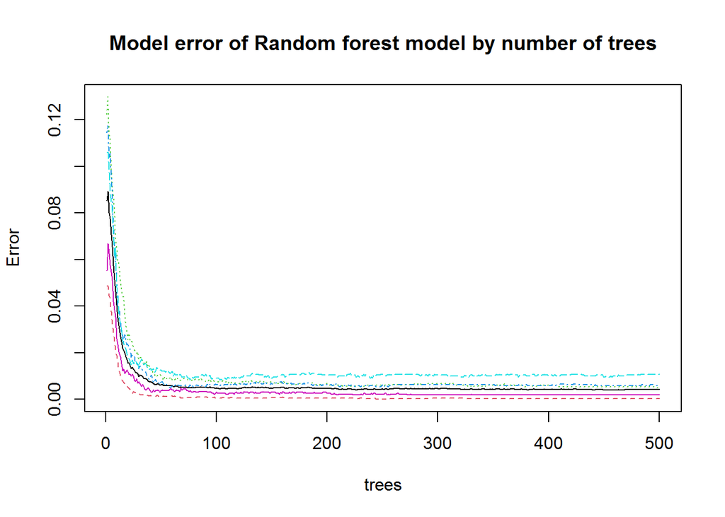

```r
Training$classe <- factor(Training$classe)
modelRF <- randomForest(classe ~. , data=Training)
plot(modelRF,main="Model error of Random forest model by number of trees")
```

```r
predictionsRF <- predict(modelRF, Testing, type = "class")
# The cross-validation
confusionMatrix(table(predictionsRF, Testing$classe))
```

```
## Confusion Matrix and Statistics
##
##
## predictionsRF    A    B    C    D    E
##             A 1394    6    0    0    0
##             B    0  941    5    0    0
##             C    0    2  848    8    0
##             D    0    0    2  795    0
##             E    1    0    0    1  901
##
## Overall Statistics
##
##                Accuracy : 0.9949
##                  95% CI : (0.9925, 0.9967)
##     No Information Rate : 0.2845
##     P-Value [Acc > NIR] : < 2.2e-16
##
##                   Kappa : 0.9936
##
##  Mcnemar's Test P-Value : NA
##
## Statistics by Class:
##
##                      Class: A Class: B Class: C Class: D Class: E
## Sensitivity            0.9993   0.9916   0.9918   0.9888   1.0000
## Specificity            0.9983   0.9987   0.9975   0.9995   0.9995
## Pos Pred Value         0.9957   0.9947   0.9883   0.9975   0.9978
## Neg Pred Value         0.9997   0.9980   0.9983   0.9978   1.0000
## Prevalence             0.2845   0.1935   0.1743   0.1639   0.1837
## Detection Rate         0.2843   0.1919   0.1729   0.1621   0.1837
## Detection Prevalence   0.2855   0.1929   0.1750   0.1625   0.1841
## Balanced Accuracy      0.9988   0.9952   0.9947   0.9942   0.9998
```